# 0.rotinas-em-r-limpeza-banco

Ana Crispim (eduLab21)

2023-07-04

# Relatório de limpeza de dados

- O objetivo deste relatório é detalhar o processo de limpeza de dados do workshop Rotinas de R para análises psicométricas. Os seguintes passos serão detalhados:
1. Abrir o banco de dados de acordo com o formato do objeto
2. Verificar se o banco segue os princípios de tidy data
3. Verificar nome das variáveis e ajustar os nomes (se necessário)
4. Verificar quantidade de variáveis por instrumento
5. Checar tipos das variáveis/colunas
6. Criar variável de identificação (se necessário)
7. Verificar observações/linhas duplicadas
8. Checar respostas descuidadas Extra: tem dados de duração da aplicação? Verifique potenciais respostas descuidadas
9. Checar dados socioeconômicos relevantes que atendam critérios de amostragem (e.g. idade mínima ou máxima)

## Amostra

- O banco de dados foi adaptado e embasado a partir do banco bfi do psychTools. Como este banco de dados foi alterado para fins didáticos, ele não pode ser compartilhado, divulgado ou usado para pesquisas. Existem N = 2806 observações com respostas e escores sobre traços de personalidade, bem-estar subjetivo, saúde mental, raciocínio lógico e diferenciação de interesses. Os 25 itens de personalidade fazem parte do projeto Synthetic Apeture Personality Assessment (SAPA) e fazem parte do International Personality Item Pool of Lewis Goldberg (IPIP)

## Passos 1 e 2: Explorar o arquivo do banco de dados

1. Abrir o banco de dados de acordo com o formato do objeto
2. Verificar se o banco segue os princípios de tidy data
- O banco de dados segue as premissas do tidy data e cada célula possui apenas um valor enquanto cada coluna representa uma variável.

```
## Rows: 2,806
## Columns: 35
## $ Identidade                 <dbl> 1, 2, 3, 4, 5, 6, 7, 8, 9, 10, 11, 12, 13, …
## $ id_estudo                  <dbl> 1, 2, 3, 4, 5, 6, 7, 8, 9, 10, 11, 12, 13, …
## $ A1                         <dbl> 2, 2, 5, 4, 2, 6, 2, 4, 4, 2, 4, 2, 5, 5, 4…
## $ A2                         <dbl> 4, 4, 4, 4, 3, 6, 5, 3, 3, 5, 4, 5, 5, 5, 5…
## $ A3                         <dbl> 3, 5, 5, 6, 3, 5, 5, 1, 6, 6, 5, 5, 5, 5, 2…
## $ A4                         <dbl> 4, 2, 4, 5, 4, 6, 3, 5, 3, 6, 6, 5, 6, 6, 2…
## $ A5                         <dbl> 4, 5, 4, 5, 5, 5, 5, 1, 3, 5, 5, 5, 4, 6, 1…
## $ C1                         <dbl> 2, 5, 4, 4, 4, 6, 5, 3, 6, 6, 4, 5, 5, 4, 5…
## $ C2                         <dbl> 3, 4, 5, 4, 4, 6, 4, 2, 6, 5, 3, 4, 4, 4, 5…
## $ C3                         <dbl> 3, 4, 4, 3, 5, 6, 4, 4, 3, 6, 5, 5, 3, 4, 5…
## $ C4                         <dbl> 4, 3, 2, 5, 3, 1, 2, 2, 4, 2, 3, 4, 2, 2, 2…
## $ C5                         <dbl> 4, 4, 5, 5, 2, 3, 3, 4, 5, 1, 2, 5, 2, 1, 2…
## $ E1                         <dbl> 3, 1, 2, 5, 2, 2, 4, 3, 5, 2, 1, 3, 3, 2, 3…
```

[output cut: 22 more lines]

## Passo 3: Verificar nome das variáveis e ajustar os nomes (se necessário)

```
##  [1] "Identidade"               "id_estudo"
##  [3] "A1"                       "A2"
##  [5] "A3"                       "A4"
##  [7] "A5"                       "C1"
##  [9] "C2"                       "C3"
## [11] "C4"                       "C5"
## [13] "E1"                       "E2"
## [15] "E3"                       "E4"
## [17] "E5"                       "N1"
## [19] "N2"                       "N3"
## [21] "N4"                       "N5"
## [23] "O1"                       "O2"
## [25] "O3"                       "O4"
## [27] "O5"                       "Genero"
## [29] "education"                "Idade"
## [31] "wb"                       "Mh"
## [33] "logic_rac"                "diferenciacao interesses"
## [35] "duracao minutos"
```

## Passo 4: Verificar quantidade de variáveis por instrumento

- Existem 25 variáveis do instrumento sobre personalidade, sendo: a) cinco perguntas sobre amabilidade, b) cinco perguntas sobre extroversão; c) cinco perguntas sobre conscienciosidade; d) cinco perguntas sobre neuroticismo; e) cinco perguntas sobre abertura.

**Ponto de atenção 1**: os nomes de variáveis com caixa alta ou espaço entre elas. A função clean_names() será usada para ajustar os nomes.  
**Ponto de atenção 2**: as características pessoais estão fora de ordem no banco de dados. A função relocate será usada para reordenar o banco de dados.  
**Ponto de atenção 3**: a variável ID está com o nome de identidade. A função rename será usada para modificar o nome.

**Ajustes realizados de acordo com pontos de atenção 1, 2 e 3:**

```
##  [1] "id"                       "id_estudo"
##  [3] "genero"                   "education"
##  [5] "idade"                    "duracao_minutos"
##  [7] "a1"                       "a2"
##  [9] "a3"                       "a4"
## [11] "a5"                       "c1"
## [13] "c2"                       "c3"
## [15] "c4"                       "c5"
## [17] "e1"                       "e2"
## [19] "e3"                       "e4"
## [21] "e5"                       "n1"
## [23] "n2"                       "n3"
## [25] "n4"                       "n5"
## [27] "o1"                       "o2"
## [29] "o3"                       "o4"
## [31] "o5"                       "wb"
## [33] "mh"                       "logic_rac"
## [35] "diferenciacao_interesses"
```

## Passo 5 e 6: Checar tipos das variáveis/colunas e variável de id

Checar tipos das variáveis/colunas

```
## Rows: 2,806
## Columns: 35
## $ id                       <dbl> 1, 2, 3, 4, 5, 6, 7, 8, 9, 10, 11, 12, 13, 14…
## $ id_estudo                <dbl> 1, 2, 3, 4, 5, 6, 7, 8, 9, 10, 11, 12, 13, 14…
## $ genero                   <dbl> 1, 2, 2, 2, 1, 2, 1, 1, 1, 2, 1, 1, 2, 1, 1, …
## $ education                <dbl> NA, NA, NA, NA, NA, 3, NA, 2, 1, NA, 1, NA, N…
## $ idade                    <chr> "16", "18", "17", "17", "17", "21", "18", "19…
## $ duracao_minutos          <dbl> 1, 21, 6, 2, 29, 29, 15, 26, 28, 25, 8, 12, 2…
## $ a1                       <dbl> 2, 2, 5, 4, 2, 6, 2, 4, 4, 2, 4, 2, 5, 5, 4, …
## $ a2                       <dbl> 4, 4, 4, 4, 3, 6, 5, 3, 3, 5, 4, 5, 5, 5, 5, …
## $ a3                       <dbl> 3, 5, 5, 6, 3, 5, 5, 1, 6, 6, 5, 5, 5, 5, 2, …
## $ a4                       <dbl> 4, 2, 4, 5, 4, 6, 3, 5, 3, 6, 6, 5, 6, 6, 2, …
## $ a5                       <dbl> 4, 5, 4, 5, 5, 5, 5, 1, 3, 5, 5, 5, 4, 6, 1, …
## $ c1                       <dbl> 2, 5, 4, 4, 4, 6, 5, 3, 6, 6, 4, 5, 5, 4, 5, …
## $ c2                       <dbl> 3, 4, 5, 4, 4, 6, 4, 2, 6, 5, 3, 4, 4, 4, 5, …
```

[output cut: 22 more lines]

**Ponto de atenção 4**: as variáveis idade, wb e mh foram identificadas como character pelo R.

- Distribuição da variável idade está normal e sem valores desconhecidos. A transformação usando a função as.numeric será feita.

| val | frq | raw.prc | cum.prc |
| --- | --- | --- | --- |
| 3 | 1 | 0.04 | 62.79 |
| 9 | 1 | 0.04 | 100.00 |
| 10 | 1 | 0.04 | 0.04 |
| 11 | 4 | 0.14 | 0.18 |
| 12 | 29 | 1.03 | 1.21 |
| 13 | 7 | 0.25 | 1.46 |
| 14 | 21 | 0.75 | 2.21 |
| 15 | 26 | 0.93 | 3.14 |
| 16 | 61 | 2.17 | 5.31 |
| 17 | 100 | 3.56 | 8.87 |
| 18 | 124 | 4.42 | 13.29 |
| 19 | 190 | 6.77 | 20.06 |
| 20 | 212 | 7.56 | 27.62 |
| 21 | 144 | 5.13 | 32.75 |
| 22 | 122 | 4.35 | 37.10 |
| 23 | 138 | 4.92 | 42.02 |
| 24 | 105 | 3.74 | 45.76 |
| 25 | 113 | 4.03 | 49.79 |
| 26 | 99 | 3.53 | 53.31 |
| 27 | 97 | 3.46 | 56.77 |
| 28 | 90 | 3.21 | 59.98 |
| 29 | 78 | 2.78 | 62.76 |
| 30 | 66 | 2.35 | 65.15 |
| 31 | 73 | 2.60 | 67.75 |
| 32 | 66 | 2.35 | 70.10 |
| 33 | 50 | 1.78 | 71.88 |
| 34 | 51 | 1.82 | 73.70 |
| 35 | 52 | 1.85 | 75.55 |
| 36 | 50 | 1.78 | 77.33 |
| 37 | 36 | 1.28 | 78.62 |
| 38 | 52 | 1.85 | 80.47 |
| 39 | 50 | 1.78 | 82.25 |
| 40 | 56 | 2.00 | 84.25 |
| 41 | 32 | 1.14 | 85.39 |
| 42 | 30 | 1.07 | 86.46 |
| 43 | 37 | 1.32 | 87.78 |
| 44 | 25 | 0.89 | 88.67 |
| 45 | 27 | 0.96 | 89.63 |
| 46 | 25 | 0.89 | 90.52 |
| 47 | 21 | 0.75 | 91.27 |
| 48 | 30 | 1.07 | 92.34 |
| 49 | 16 | 0.57 | 92.91 |
| 50 | 34 | 1.21 | 94.12 |
| 51 | 24 | 0.86 | 94.98 |
| 52 | 26 | 0.93 | 95.90 |
| 53 | 17 | 0.61 | 96.51 |
| 54 | 14 | 0.50 | 97.01 |
| 55 | 17 | 0.61 | 97.61 |
| 56 | 17 | 0.61 | 98.22 |
| 57 | 9 | 0.32 | 98.54 |
| 58 | 7 | 0.25 | 98.79 |
| 59 | 5 | 0.18 | 98.97 |
| 60 | 6 | 0.21 | 99.18 |
| 61 | 4 | 0.14 | 99.32 |
| 62 | 4 | 0.14 | 99.47 |
| 63 | 3 | 0.11 | 99.57 |
| 64 | 1 | 0.04 | 99.61 |
| 65 | 1 | 0.04 | 99.64 |
| 66 | 1 | 0.04 | 99.68 |
| 67 | 3 | 0.11 | 99.79 |
| 68 | 1 | 0.04 | 99.82 |
| 70 | 1 | 0.04 | 99.86 |
| 72 | 1 | 0.04 | 99.89 |
| 74 | 1 | 0.04 | 99.93 |
| 86 | 1 | 0.04 | 99.96 |
| NA | 0 | 0.00 | NA |

| val | frq | raw.prc | cum.prc |
| --- | --- | --- | --- |
| 1 | 573 | 20.42 | 20.42 |
| 2 | 908 | 32.36 | 52.78 |
| 3 | 592 | 21.10 | 73.88 |
| 4 | 439 | 15.65 | 89.52 |
| 5 | 214 | 7.63 | 97.15 |
| 6 | 79 | 2.82 | 99.96 |
| x | 1 | 0.04 | 100.00 |
| NA | 0 | 0.00 | NA |

- Distribuição da variável mh tem um valor desconhecido, “x”. A transformação usando a função as.numeric será feita após usar a função mutate + na_if.

| val | frq | raw.prc | cum.prc |
| --- | --- | --- | --- |
| 1 | 577 | 20.56 | 20.56 |
| 2 | 910 | 32.43 | 52.99 |
| 3 | 560 | 19.96 | 72.95 |
| 4 | 454 | 16.18 | 89.13 |
| 5 | 225 | 8.02 | 97.15 |
| 6 | 79 | 2.82 | 99.96 |
| x | 1 | 0.04 | 100.00 |
| NA | 0 | 0.00 | NA |

## Passo 7: Verificar observações/linhas duplicadas

- Foram encontrados dois casos duplicados de acordo com a variável id: 2801 e 2804. A partir dessa informação foi identificado o id_estudo para verificar se foi imputado de forma igual, oq ue foi o caso. Aqui, pode ser hipotetizado que houve uma falha no sistema que gravou a resposta de uma mesma pessoas duas vezes.
- Casos removidos com base em id_estudo: **2805 e 2806**.

## Passo 8: Checagem respostas descuidadas

### Pacote careless e respostas repetidas

**Resultado:** Por volta de **0.28%** dos participantes respondeu da mesma forma em mais da metade do questionário. Esses participantes serão removidos da amostra.

| val | frq | raw.prc | cum.prc |
| --- | --- | --- | --- |
| 1 | 5 | 0.18 | 0.18 |
| 2 | 612 | 21.83 | 22.00 |
| 3 | 1110 | 39.59 | 61.59 |
| 4 | 615 | 21.93 | 83.52 |
| 5 | 292 | 10.41 | 93.94 |
| 6 | 95 | 3.39 | 97.33 |
| 7 | 47 | 1.68 | 99.00 |
| 8 | 14 | 0.50 | 99.50 |
| 9 | 5 | 0.18 | 99.68 |
| 10 | 1 | 0.04 | 99.71 |
| 16 | 4 | 0.14 | 99.86 |
| 25 | 4 | 0.14 | 100.00 |
| NA | 0 | 0.00 | NA |

### Tempo de resposta do survey

- Em média, as pessoas demoraram por volta de **15 minutos** para responder ao questionário, variando entre 1 e 30 minutos.

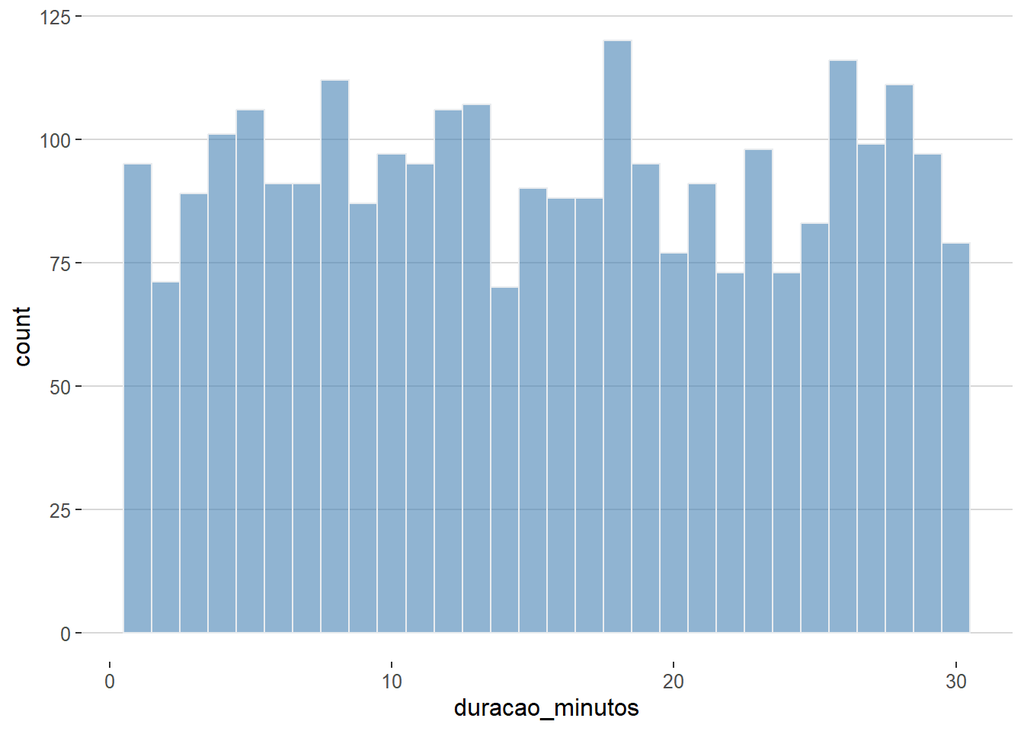

### Cálculo respostas descuidadas via média e DP

- Essa visualização permite identificar casos com médias altas ou baixas com baixo DP. O que quer dizer que são casos que não estão variando suas respostas de forma substancial. Isso é um indicador de atenção para o pesquisador.

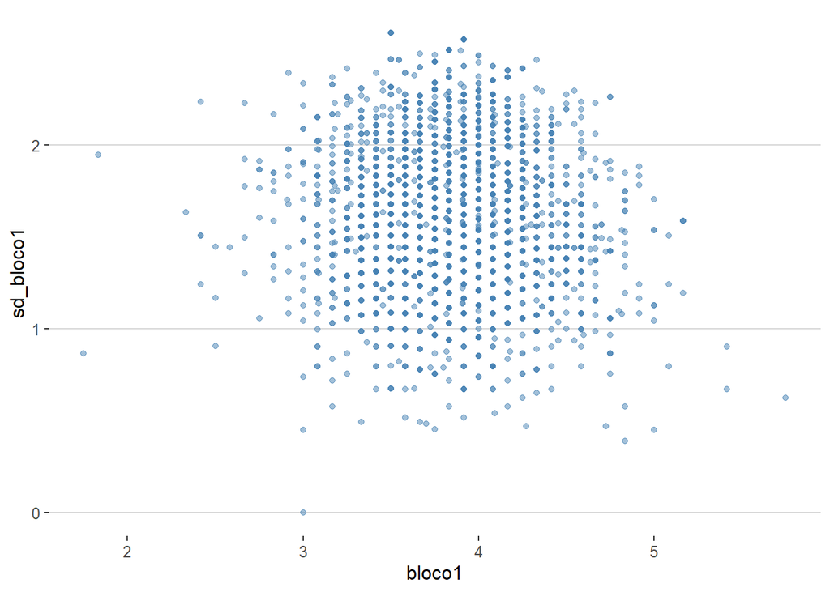

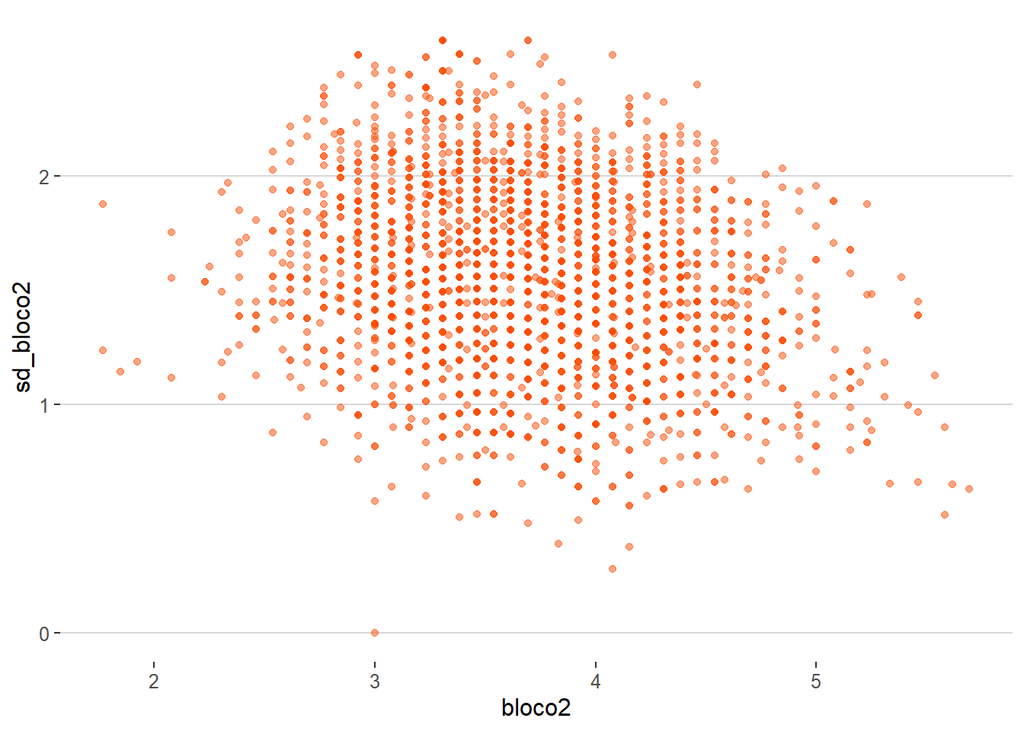

## Passo 9: Checar dados socioeconômicos relevantes que atendam critérios de amostragem (e.g. idade mínima ou máxima)

- Gênero (1 = meninos, 2 = meninas)

| val | frq | raw.prc | cum.prc |
| --- | --- | --- | --- |
| 1 | 915 | 32.73 | 32.73 |
| 2 | 1881 | 67.27 | 100.00 |
| NA | 0 | 0.00 | NA |

- Escolaridade (1 = HS, 2 = finished HS, 3 = some college, 4 = college graduate 5 = graduate degree)

| val | frq | raw.prc | cum.prc |
| --- | --- | --- | --- |
| 1 | 224 | 8.01 | 8.71 |
| 2 | 292 | 10.44 | 20.05 |
| 3 | 1245 | 44.53 | 68.44 |
| 4 | 394 | 14.09 | 83.75 |
| 5 | 418 | 14.95 | 100.00 |
| NA | 223 | 7.98 | NA |

- Distribuição da idade

**Importante:** o estudo se refere apenas a população adulta, portanto, participantes com menos de 18 anos foram retirados da amostra, resultado em *N = 2545* para as análises de dados.

Data summary

| Name | bfi_fake$idade |
| --- | --- |
| Number of rows | 2545 |
| Number of columns | 1 |
| _______________________ |  |
| Column type frequency: |  |
| numeric | 1 |
| ________________________ |  |
| Group variables | None |

**Variable type: numeric**

| skim_variable | n_missing | complete_rate | mean | sd | p0 | p25 | p50 | p75 | p100 | hist |
| --- | --- | --- | --- | --- | --- | --- | --- | --- | --- | --- |
| data | 0 | 1 | 30.08 | 10.8 | 18 | 21 | 27 | 36 | 86 | ▇▃▁▁▁ |

### Considerações

- O banco de dados foi salvo na pasta data, seguindo as boas práticas de R e com nome *bfi_fake.RDS*.
- O tamanho da amostra final é *N = 2545 participantes.*